# Master Report: Comparative Explainability of Hospital Preference Models

This notebook compares three trained models on the same test alternatives:

- XGBoost with monotone constraints
- ANN-UTADIS
- Standard PyTorch Neural Network

Models are analysed with SHAP and DALEX

```python
from __future__ import annotations

from pathlib import Path
import sys
import warnings

import numpy as np
import pandas as pd
import matplotlib.pyplot as plt
import seaborn as sns

import torch
import torch.nn as nn

from sklearn.model_selection import train_test_split
from sklearn.preprocessing import StandardScaler
from sklearn.metrics import (
    ConfusionMatrixDisplay,
    RocCurveDisplay,
    confusion_matrix,
)
from sklearn.inspection import permutation_importance, PartialDependenceDisplay

import joblib

warnings.filterwarnings("ignore")

pd.set_option("display.max_columns", 200)
np.set_printoptions(precision=4, suppress=True)

SEED = 42
np.random.seed(SEED)
torch.manual_seed(SEED)

plt.style.use("seaborn-v0_8-whitegrid")
sns.set_context("talk")

CWD = Path.cwd().resolve()
PROJECT_ROOT = CWD if (CWD / "src").exists() else CWD.parent
if str(PROJECT_ROOT) not in sys.path:
    sys.path.insert(0, str(PROJECT_ROOT))

from src.metrics import evaluate_model
from src.ann_utadis import (
    PreferenceMinMaxScaler,
    load_ann_utadis_bundle,
    predict_ann_utadis,
)

DATA_PATH = PROJECT_ROOT / "data" / "hospital_data.csv"
MODELS_DIR = PROJECT_ROOT / "models"

print(f"Current working dir: {CWD}")
print(f"Project root: {PROJECT_ROOT}")
print(f"Data path exists: {DATA_PATH.exists()}")
print(f"Models dir exists: {MODELS_DIR.exists()}")
```

```
Current working dir: /home/marek/put/DA/mcda/notebooks
Project root: /home/marek/put/DA/mcda
Data path exists: True
Models dir exists: True
```

```python
HAS_SHAP = True
HAS_DALEX = True

try:
    import shap
except Exception:
    HAS_SHAP = False

try:
    import dalex as dx
except Exception:
    HAS_DALEX = False

print(f"SHAP available: {HAS_SHAP}")
print(f"DALEX available: {HAS_DALEX}")
if not HAS_SHAP or not HAS_DALEX:
    print("If needed: pip install shap dalex")
```

```
SHAP available: True
DALEX available: True
```

## Dataset Description

This dataset is constructed from publicly available hospital quality data provided by the Centers for Medicare & Medicaid Services (CMS) as part of the Hospital Compare initiative. It combines selected indicators related to mortality, complications, readmissions, safety, and cost efficiency at the hospital level.

#### Features:

- mort_ami (cost) 30-day mortality rate for heart attack (AMI) patients. Lower values indicate lower mortality and better performance.
- comp_hip_knee (cost) complication rate for hip and knee replacement procedures. Lower values indicate fewer complications.
- readmission_hf (cost) measure of hospital return days for heart failure patients. Lower values indicate fewer readmissions.
- spending (cost) Medicare Spending per Beneficiary (MSPB) score. Lower values indicate better cost efficiency.
- count_of_safety_measures_better (gain) Number of safety-related measures where the hospital performs better than the national average. Higher values indicate better safety performance
- count_of_readm_measures_worse (cost) number of readmission measures where the hospital performs worse than the national average. Lower values indicate better performance.

#### Target Variable

- hospital_overall_rating Overall hospital rating on a 1–5 star scale. This is an ordinal variable representing overall quality and is used as the target for preference learning.

```python
eda_df = pd.read_csv(DATA_PATH)

eda_cost_cols = [
    "mort_ami",
    "comp_hip_knee",
    "readmission_hf",
    "spending",
    "count_of_readm_measures_worse",
]
eda_gain_cols = ["count_of_safety_measures_better"]
eda_feature_cols = eda_cost_cols + eda_gain_cols

feature_info = pd.DataFrame(
    {
        "feature": eda_feature_cols,
        "criterion_type": ["cost" if c in eda_cost_cols else "gain" for c in eda_feature_cols],
        "min": [float(eda_df[c].min()) for c in eda_feature_cols],
        "max": [float(eda_df[c].max()) for c in eda_feature_cols],
        "mean": [float(eda_df[c].mean()) for c in eda_feature_cols],
        "std": [float(eda_df[c].std()) for c in eda_feature_cols],
        "q05": [float(eda_df[c].quantile(0.05)) for c in eda_feature_cols],
        "q95": [float(eda_df[c].quantile(0.95)) for c in eda_feature_cols],
    }
)

print(f"Rows: {len(eda_df)}, Columns: {eda_df.shape[1]}")
print(f"Missing values (total): {int(eda_df.isna().sum().sum())}")
print("\nFeature range summary:")
display(feature_info.round(4))
```

[output not shown]

|  | feature | criterion_type | min | max | mean | std | q05 | q95 |
| --- | --- | --- | --- | --- | --- | --- | --- | --- |
| 0 | mort_ami | cost | 9.10 | 17.30 | 12.6112 | 1.3216 | 10.500 | 15.000 |
| 1 | comp_hip_knee | cost | 1.60 | 6.20 | 3.4960 | 0.6580 | 2.595 | 4.700 |
| 2 | readmission_hf | cost | -42.10 | 75.30 | 4.0730 | 19.7347 | -25.905 | 39.115 |
| 3 | spending | cost | 0.83 | 1.21 | 0.9986 | 0.0554 | 0.910 | 1.100 |
| 4 | count_of_readm_measures_worse | cost | 0.00 | 6.00 | 1.0300 | 1.1043 | 0.000 | 3.000 |
| 5 | count_of_safety_measures_better | gain | 0.00 | 6.00 | 1.4780 | 1.1296 | 0.000 | 4.000 |

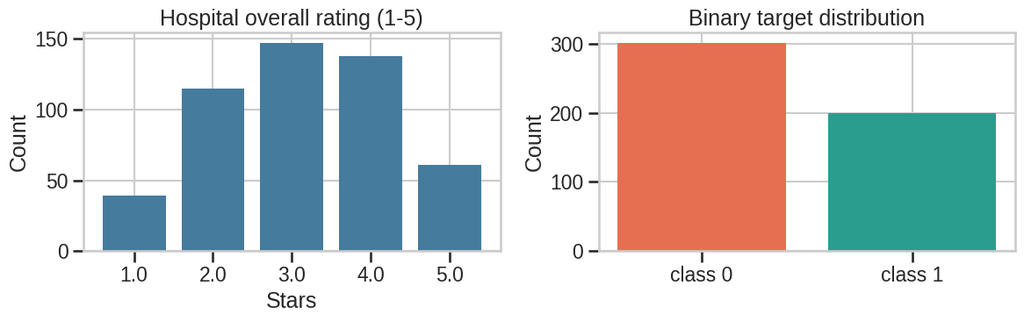

```
Class share -> class 0: 0.602, class 1: 0.398
```

```python
rating_counts = eda_df["hospital_overall_rating"].value_counts().sort_index()
eda_df["target"] = (eda_df["hospital_overall_rating"] >= 4).astype(int)
target_counts = eda_df["target"].value_counts().sort_index()

fig, axes = plt.subplots(1, 2, figsize=(12, 4))

axes[0].bar(rating_counts.index.astype(str), rating_counts.values, color="#457B9D")
axes[0].set_title("Hospital overall rating (1-5)")
axes[0].set_xlabel("Stars")
axes[0].set_ylabel("Count")

axes[1].bar(["class 0", "class 1"], [target_counts.get(0, 0), target_counts.get(1, 0)], color=["#E76F51", "#2A9D8F"])
axes[1].set_title("Binary target distribution")
axes[1].set_ylabel("Count")

plt.tight_layout()
plt.show()

print(
    f"Class share -> class 0: {target_counts.get(0, 0)/len(eda_df):.3f}, "
    f"class 1: {target_counts.get(1, 0)/len(eda_df):.3f}"
)
```

## Data Preparation and Common Split

All models are compared on exactly the same train/test split and target definition:

y = 1 IF hospital_overall_rating >= 4 , where rating is given on a scale from 1 to 5 in terms of stars

```python
df = pd.read_csv(DATA_PATH)

cost_cols = [
    "mort_ami",
    "comp_hip_knee",
    "readmission_hf",
    "spending",
    "count_of_readm_measures_worse",
]
gain_cols = ["count_of_safety_measures_better"]
feature_cols = cost_cols + gain_cols
meta_cols = ["facility_id", "facility_name"]

df["target"] = (df["hospital_overall_rating"] >= 4).astype(int)

X_all = df[feature_cols].copy()
y_all = df["target"].values
meta_all = df[meta_cols].copy()

X_train_raw, X_test_raw, y_train, y_test, meta_train, meta_test = train_test_split(
    X_all,
    y_all,
    meta_all,
    test_size=0.2,
    random_state=SEED,
    stratify=y_all,
)

X_train_raw = X_train_raw.reset_index(drop=True)
X_test_raw = X_test_raw.reset_index(drop=True)
meta_test = meta_test.reset_index(drop=True)

print("Train shape:", X_train_raw.shape)
print("Test shape:", X_test_raw.shape)
print("Class balance (test):", np.bincount(y_test))
```

```
Train shape: (400, 6)
Test shape: (100, 6)
Class balance (test): [60 40]
```

## Load Trained Models and Build Unified Predictors

```python
class StandardNN(nn.Module):
    def __init__(self, input_size: int = 6):
        super().__init__()
        self.layer1 = nn.Linear(input_size, 8)
        self.relu1 = nn.ReLU()
        self.dropout1 = nn.Dropout(0.2)
        self.layer2 = nn.Linear(8, 4)
        self.relu2 = nn.ReLU()
        self.dropout2 = nn.Dropout(0.2)
        self.output = nn.Linear(4, 1)
        self.sigmoid = nn.Sigmoid()

    def forward(self, x):
        x = self.layer1(x)
        x = self.relu1(x)
        x = self.dropout1(x)
        x = self.layer2(x)
        x = self.relu2(x)
        x = self.dropout2(x)
        x = self.output(x)
        x = self.sigmoid(x)
        return x

# XGBoost
xgb_bundle = joblib.load(MODELS_DIR / "xgboost_hospital_monotonic.joblib")
xgb_model = xgb_bundle["model"]

# StandardNN
nn_bundle = torch.load(MODELS_DIR / "standard_nn_hospital.pt", map_location="cpu")
stdnn_model = StandardNN(input_size=len(feature_cols))
stdnn_model.load_state_dict(nn_bundle["model_state_dict"])
stdnn_model.eval()

stdnn_meta = nn_bundle["metadata"]
stdnn_scaler = StandardScaler()
stdnn_scaler.mean_ = np.array(stdnn_meta["scaler_mean"], dtype=float)
stdnn_scaler.scale_ = np.array(stdnn_meta["scaler_scale"], dtype=float)
stdnn_scaler.var_ = stdnn_scaler.scale_ ** 2
stdnn_scaler.n_features_in_ = len(feature_cols)

# ANN-UTADIS
ann_model, ann_meta = load_ann_utadis_bundle(MODELS_DIR / "ann_utadis_hospital.pt", map_location="cpu")
ann_scaler = PreferenceMinMaxScaler(gain_columns=gain_cols, cost_columns=cost_cols)
ann_scaler.min_ = {k: float(v) for k, v in ann_meta["scaler_min"].items()}
ann_scaler.max_ = {k: float(v) for k, v in ann_meta["scaler_max"].items()}

print("Loaded models: XGBoost, StandardNN, ANN-UTADIS")
```

```
Loaded models: XGBoost, StandardNN, ANN-UTADIS
```

```python
def predict_xgb(X_raw: pd.DataFrame) -> tuple[np.ndarray, np.ndarray]:
    y_prob = xgb_model.predict_proba(X_raw[feature_cols])[:, 1]
    y_pred = (y_prob >= 0.5).astype(int)
    return y_pred, y_prob


def predict_stdnn(X_raw: pd.DataFrame) -> tuple[np.ndarray, np.ndarray]:
    X_scaled = stdnn_scaler.transform(X_raw[feature_cols].values)
    with torch.no_grad():
        probs = stdnn_model(torch.tensor(X_scaled, dtype=torch.float32)).cpu().numpy().reshape(-1)
    preds = (probs >= 0.5).astype(int)
    return preds, probs


def predict_ann(X_raw: pd.DataFrame) -> tuple[np.ndarray, np.ndarray]:
    X_norm = ann_scaler.transform(X_raw[feature_cols])
    preds, probs = predict_ann_utadis(ann_model, X_norm.values)
    return preds.reshape(-1).astype(int), probs.reshape(-1)


predictors = {
    "XGBoost": predict_xgb,
    "StandardNN": predict_stdnn,
    "ANN-UTADIS": predict_ann,
}

for model_name, fn in predictors.items():
    p, s = fn(X_test_raw)
    print(model_name, p.shape, s.shape, f"prob-range=({s.min():.4f}, {s.max():.4f})")
```

```
XGBoost (100,) (100,) prob-range=(0.0092, 0.9709)
StandardNN (100,) (100,) prob-range=(0.0324, 0.8566)
ANN-UTADIS (100,) (100,) prob-range=(0.4527, 0.5483)
```

```python
def fmt4(x: float) -> float:
    return round(float(x), 4)


def compute_metrics_table(X_raw: pd.DataFrame, y_true: np.ndarray) -> pd.DataFrame:
    rows = []
    for model_name, fn in predictors.items():
        y_pred, y_prob = fn(X_raw)
        m = evaluate_model(y_true, y_pred, y_prob)
        rows.append({"model": model_name, **m})
    out = pd.DataFrame(rows).set_index("model").sort_index()
    return out


# Consistency checks before comparative analysis
assert list(feature_cols) == list(xgb_bundle["feature_cols"]), "Feature order mismatch in XGBoost bundle"
assert list(feature_cols) == list(stdnn_meta["feature_cols"]), "Feature order mismatch in StandardNN bundle"
assert list(feature_cols) == list(ann_meta["feature_cols"]), "Feature order mismatch in ANN-UTADIS bundle"
assert len(X_test_raw) == len(y_test), "Test feature/label size mismatch"

metrics_df = compute_metrics_table(X_test_raw, y_test)
metrics_df
```

| model | accuracy | f1 | auc |
| --- | --- | --- | --- |
| ANN-UTADIS | 0.79 | 0.7692 | 0.9050 |
| StandardNN | 0.83 | 0.7848 | 0.8962 |
| XGBoost | 0.79 | 0.7200 | 0.8533 |

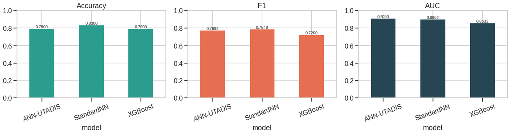

```python
fig, axes = plt.subplots(1, 3, figsize=(18, 5))

metrics_df["accuracy"].plot(kind="bar", ax=axes[0], color="#2A9D8F")
axes[0].set_title("Accuracy")
axes[0].set_ylim(0, 1)

metrics_df["f1"].plot(kind="bar", ax=axes[1], color="#E76F51")
axes[1].set_title("F1")
axes[1].set_ylim(0, 1)

metrics_df["auc"].plot(kind="bar", ax=axes[2], color="#264653")
axes[2].set_title("AUC")
axes[2].set_ylim(0, 1)

for ax in axes:
    ax.tick_params(axis="x", rotation=20)
    for container in ax.containers:
        ax.bar_label(container, fmt="%.4f", fontsize=10)

plt.tight_layout()
plt.show()
```

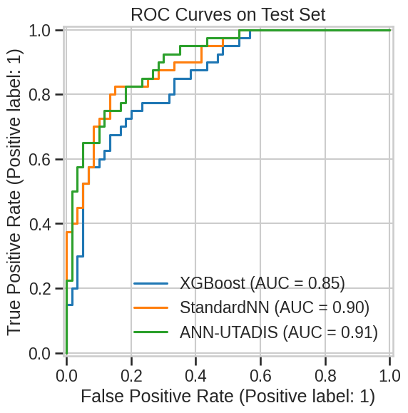

```python
fig, ax = plt.subplots(figsize=(8, 6))
for model_name, fn in predictors.items():
    y_pred, y_prob = fn(X_test_raw)
    RocCurveDisplay.from_predictions(y_test, y_prob, name=model_name, ax=ax)

ax.set_title("ROC Curves on Test Set")
plt.show()
```

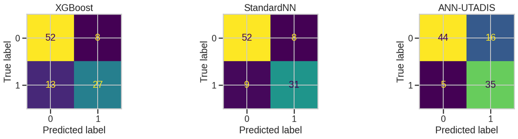

```python
fig, axes = plt.subplots(1, 3, figsize=(16, 4))
for ax, (model_name, fn) in zip(axes, predictors.items()):
    y_pred, _ = fn(X_test_raw)
    cm = confusion_matrix(y_test, y_pred)
    disp = ConfusionMatrixDisplay(cm)
    disp.plot(ax=ax, colorbar=False)
    ax.set_title(model_name)

plt.tight_layout()
plt.show()
```

## Explanation of Decisions for 3 Alternatives

We select:

- one clear negative (lowest confidence for class 1),
- one borderline case (closest probability to 0.5),
- one clear positive (highest confidence for class 1).

For each selected alternative we provide:

1. local feature-attribution explanation,
2. minimum single-criterion change to flip class:
- analytical/numerical root-based method,
- sampling-based method (step (0.01) in normalized criterion space).

```python
# Select 3 alternatives using XGBoost confidence as anchor (shared objects for all models)
xgb_pred, xgb_prob = predict_xgb(X_test_raw)

idx_neg = int(np.argmin(xgb_prob))
idx_pos = int(np.argmax(xgb_prob))
idx_border = int(np.argmin(np.abs(xgb_prob - 0.5)))

selected_indices = {
    "clear_negative": idx_neg,
    "borderline": idx_border,
    "clear_positive": idx_pos,
}

selected_df = pd.DataFrame({
    "case": list(selected_indices.keys()),
    "test_index": list(selected_indices.values()),
})
selected_df["facility_name"] = selected_df["test_index"].map(lambda i: meta_test.loc[i, "facility_name"])
selected_df["xgb_prob"] = selected_df["test_index"].map(lambda i: fmt4(xgb_prob[i]))
selected_df["y_true"] = selected_df["test_index"].map(lambda i: int(y_test[i]))
selected_df
```

|  | case | test_index | facility_name | xgb_prob | y_true |
| --- | --- | --- | --- | --- | --- |
| 0 | clear_negative | 35 | PRESENCE SAINT JOSEPH MEDICAL CENTER | 0.0092 | 0 |
| 1 | borderline | 0 | COMMUNITY HOSPITAL OF ANDERSON AND MADISON COUNTY | 0.4996 | 0 |
| 2 | clear_positive | 53 | LANCASTER GENERAL HOSPITAL | 0.9709 | 1 |

```python
local_pred_cache = {}
for model_name, fn in predictors.items():
    y_pred_m, y_prob_m = fn(X_test_raw)
    local_pred_cache[model_name] = {"pred": y_pred_m, "prob": y_prob_m}

rows = []
for case, idx in selected_indices.items():
    row = {
        "case": case,
        "test_index": idx,
        "true_class": int(y_test[idx]),
    }
    for model_name in predictors:
        row[f"{model_name}_pred"] = int(local_pred_cache[model_name]["pred"][idx])
        row[f"{model_name}_prob"] = fmt4(local_pred_cache[model_name]["prob"][idx])
    rows.append(row)

pd.DataFrame(rows)
```

|  | case | test_index | true_class | XGBoost_pred | XGBoost_prob | StandardNN_pred | StandardNN_prob | ANN-UTADIS_pred | ANN-UTADIS_prob |
| --- | --- | --- | --- | --- | --- | --- | --- | --- | --- |
| 0 | clear_negative | 35 | 0 | 0 | 0.0092 | 0 | 0.0504 | 0 | 0.4688 |
| 1 | borderline | 0 | 0 | 0 | 0.4996 | 0 | 0.3526 | 0 | 0.4952 |
| 2 | clear_positive | 53 | 1 | 1 | 0.9709 | 1 | 0.8544 | 1 | 0.5414 |

```python
def model_prob(model_name: str, X_raw: pd.DataFrame) -> np.ndarray:
    return predictors[model_name](X_raw)[1]


def _raw_to_unit(feature: str, raw_value: float, X_reference: pd.DataFrame) -> float:
    fmin = float(X_reference[feature].min())
    fmax = float(X_reference[feature].max())
    if fmax - fmin <= 1e-12:
        return 0.0
    if feature in gain_cols:
        return (raw_value - fmin) / (fmax - fmin)
    return 1.0 - (raw_value - fmin) / (fmax - fmin)


def _unit_to_raw(feature: str, unit_value: float, X_reference: pd.DataFrame) -> float:
    unit_value = float(np.clip(unit_value, 0.0, 1.0))
    fmin = float(X_reference[feature].min())
    fmax = float(X_reference[feature].max())
    if feature in gain_cols:
        return fmin + unit_value * (fmax - fmin)
    return fmin + (1.0 - unit_value) * (fmax - fmin)


def _class_for_value(model_name: str, x0_raw: pd.Series, feature: str, value: float) -> int:
    x_new = x0_raw.copy()
    x_new[feature] = value
    p = float(model_prob(model_name, pd.DataFrame([x_new]))[0])
    return int(p >= 0.5)


def _bisection_boundary(
    model_name: str,
    x0_raw: pd.Series,
    feature: str,
    left: float,
    right: float,
    max_iter: int = 80,
    tol: float = 1e-6,
) -> float:
    """Find decision boundary p=0.5 in [left, right] assuming a class change exists."""
    f_left = float(model_prob(model_name, pd.DataFrame([{**x0_raw.to_dict(), feature: left}]))[0] - 0.5)
    f_right = float(model_prob(model_name, pd.DataFrame([{**x0_raw.to_dict(), feature: right}]))[0] - 0.5)

    l, r = float(left), float(right)
    for _ in range(max_iter):
        mid = 0.5 * (l + r)
        f_mid = float(model_prob(model_name, pd.DataFrame([{**x0_raw.to_dict(), feature: mid}]))[0] - 0.5)
        if abs(r - l) < tol:
            return mid
        if f_left * f_mid <= 0:
            r = mid
            f_right = f_mid
        else:
            l = mid
            f_left = f_mid
    return 0.5 * (l + r)


def _find_nearest_flip_value(
    model_name: str,
    x0_raw: pd.Series,
    feature: str,
    grid_points: int = 401,
) -> float | None:
    """Deterministic search for the nearest single-feature class flip value."""
    cls0 = _class_for_value(model_name, x0_raw, feature, float(x0_raw[feature]))
    low = float(X_train_raw[feature].min())
    high = float(X_train_raw[feature].max())

    grid = np.linspace(low, high, grid_points)
    classes = np.array([_class_for_value(model_name, x0_raw, feature, g) for g in grid], dtype=int)
    flip_idx = np.where(classes != cls0)[0]
    if len(flip_idx) == 0:
        return None

    x0_val = float(x0_raw[feature])
    idx_best = int(flip_idx[np.argmin(np.abs(grid[flip_idx] - x0_val))])

    left_idx = max(0, idx_best - 1)
    right_idx = min(len(grid) - 1, idx_best + 1)

    while left_idx > 0 and classes[left_idx] == classes[right_idx]:
        left_idx -= 1
    while right_idx < len(grid) - 1 and classes[left_idx] == classes[right_idx]:
        right_idx += 1

    if classes[left_idx] == classes[right_idx]:
        return float(grid[idx_best])

    boundary = _bisection_boundary(
        model_name=model_name,
        x0_raw=x0_raw,
        feature=feature,
        left=float(grid[left_idx]),
        right=float(grid[right_idx]),
    )

    cls_boundary = _class_for_value(model_name, x0_raw, feature, boundary)
    if cls_boundary == cls0:
        direction = 1.0 if float(grid[idx_best]) > boundary else -1.0
        eps = 1e-4 * (high - low if high > low else 1.0)
        candidate = float(np.clip(boundary + direction * eps, low, high))
        if _class_for_value(model_name, x0_raw, feature, candidate) != cls0:
            return candidate
        return None

    return float(boundary)


def analytical_min_change_single_feature(model_name: str, x0_raw: pd.Series) -> dict:
    best = None
    for feat in feature_cols:
        root = _find_nearest_flip_value(model_name, x0_raw, feat)
        if root is None:
            continue
        delta_raw = float(root - x0_raw[feat])
        delta_unit = _raw_to_unit(feat, root, X_train_raw) - _raw_to_unit(feat, float(x0_raw[feat]), X_train_raw)
        candidate = {
            "feature": feat,
            "new_value": float(root),
            "delta_raw": delta_raw,
            "delta_unit": float(delta_unit),
            "abs_delta_unit": float(abs(delta_unit)),
        }
        if best is None or candidate["abs_delta_unit"] < best["abs_delta_unit"]:
            best = candidate

    return best if best is not None else {
        "feature": None,
        "new_value": None,
        "delta_raw": None,
        "delta_unit": None,
        "abs_delta_unit": None,
    }


def sampling_min_change_single_feature(
    model_name: str,
    x0_raw: pd.Series,
    step: float = 0.01,
) -> dict:
    p0 = float(model_prob(model_name, pd.DataFrame([x0_raw]))[0])
    cls0 = int(p0 >= 0.5)
    best = None

    for feat in feature_cols:
        u0 = _raw_to_unit(feat, float(x0_raw[feat]), X_train_raw)
        for direction in (-1.0, 1.0):
            k = 0
            while k <= int(1.0 / step) + 2:
                u = u0 + direction * k * step
                if not (0.0 <= u <= 1.0):
                    break
                raw_new = _unit_to_raw(feat, u, X_train_raw)
                x_new = x0_raw.copy()
                x_new[feat] = raw_new
                p_new = float(model_prob(model_name, pd.DataFrame([x_new]))[0])
                cls_new = int(p_new >= 0.5)
                if cls_new != cls0:
                    delta_u = float(u - u0)
                    cand = {
                        "feature": feat,
                        "new_value": float(raw_new),
                        "delta_raw": float(raw_new - x0_raw[feat]),
                        "delta_unit": delta_u,
                        "abs_delta_unit": float(abs(delta_u)),
                    }
                    if best is None or cand["abs_delta_unit"] < best["abs_delta_unit"]:
                        best = cand
                    break
                k += 1

    return best if best is not None else {
        "feature": None,
        "new_value": None,
        "delta_raw": None,
        "delta_unit": None,
        "abs_delta_unit": None,
    }
```

```python
# Compare analytical vs sampling minimum-change on selected alternatives
flip_rows = []
for case, idx in selected_indices.items():
    x0 = X_test_raw.loc[idx, feature_cols]
    for model_name in predictors:
        analytical = analytical_min_change_single_feature(model_name, x0)
        sampled = sampling_min_change_single_feature(model_name, x0, step=0.01)

        err = None
        agree = None
        if analytical["abs_delta_unit"] is not None and sampled["abs_delta_unit"] is not None:
            err = abs(float(analytical["abs_delta_unit"]) - float(sampled["abs_delta_unit"]))
            agree = err <= 0.01

        flip_rows.append({
            "case": case,
            "model": model_name,
            "analytical_feature": analytical["feature"],
            "analytical_abs_delta_unit": None if analytical["abs_delta_unit"] is None else fmt4(analytical["abs_delta_unit"]),
            "sampling_feature": sampled["feature"],
            "sampling_abs_delta_unit": None if sampled["abs_delta_unit"] is None else fmt4(sampled["abs_delta_unit"]),
            "abs_error": None if err is None else fmt4(err),
            "agreement_within_0.01": agree,
            "flip_found_analytical": analytical["feature"] is not None,
            "flip_found_sampling": sampled["feature"] is not None,
            "no_single_feature_flip_in_range": (analytical["feature"] is None) and (sampled["feature"] is None),
        })

flip_cmp_df = pd.DataFrame(flip_rows)

show_df = flip_cmp_df.copy()
for col in ["analytical_feature", "sampling_feature"]:
    show_df[col] = show_df[col].fillna("NO_FLIP")
for col in ["analytical_abs_delta_unit", "sampling_abs_delta_unit", "abs_error"]:
    show_df[col] = show_df[col].astype(object).where(show_df[col].notna(), "NO_FLIP")

print("No-flip rows:", int(show_df["no_single_feature_flip_in_range"].sum()))
print("Rows with analytical flip only:", int(((show_df["flip_found_analytical"]) & (~show_df["flip_found_sampling"])).sum()))
print("Rows with both found:", int(((show_df["flip_found_analytical"]) & (show_df["flip_found_sampling"])).sum()))

show_df
```

```
No-flip rows: 5
Rows with analytical flip only: 0
Rows with both found: 4
```

|  | case | model | analytical_feature | analytical_abs_delta_unit | sampling_feature | sampling_abs_delta_unit | abs_error | agreement_within_0.01 | flip_found_analytical | flip_found_sampling | no_single_feature_flip_in_range |
| --- | --- | --- | --- | --- | --- | --- | --- | --- | --- | --- | --- |
| 0 | clear_negative | XGBoost | NO_FLIP | NO_FLIP | NO_FLIP | NO_FLIP | NO_FLIP | None | False | False | True |
| 1 | clear_negative | StandardNN | NO_FLIP | NO_FLIP | NO_FLIP | NO_FLIP | NO_FLIP | None | False | False | True |
| 2 | clear_negative | ANN-UTADIS | spending | 0.663 | spending | 0.67 | 0.007 | True | True | True | False |
| 3 | borderline | XGBoost | spending | 0.0263 | spending | 0.03 | 0.0037 | True | True | True | False |
| 4 | borderline | StandardNN | mort_ami | 0.1541 | mort_ami | 0.16 | 0.0059 | True | True | True | False |
| 5 | borderline | ANN-UTADIS | readmission_hf | 0.0645 | readmission_hf | 0.07 | 0.0055 | True | True | True | False |
| 6 | clear_positive | XGBoost | NO_FLIP | NO_FLIP | NO_FLIP | NO_FLIP | NO_FLIP | None | False | False | True |
| 7 | clear_positive | StandardNN | NO_FLIP | NO_FLIP | NO_FLIP | NO_FLIP | NO_FLIP | None | False | False | True |
| 8 | clear_positive | ANN-UTADIS | NO_FLIP | NO_FLIP | NO_FLIP | NO_FLIP | NO_FLIP | None | False | False | True |

### ANN-UTADIS: Marginal Utility Functions and Alternative Positions

This subsection visualizes criterion-level marginal utilities learned by ANN-UTADIS and overlays points for the three selected alternatives on each criterion.

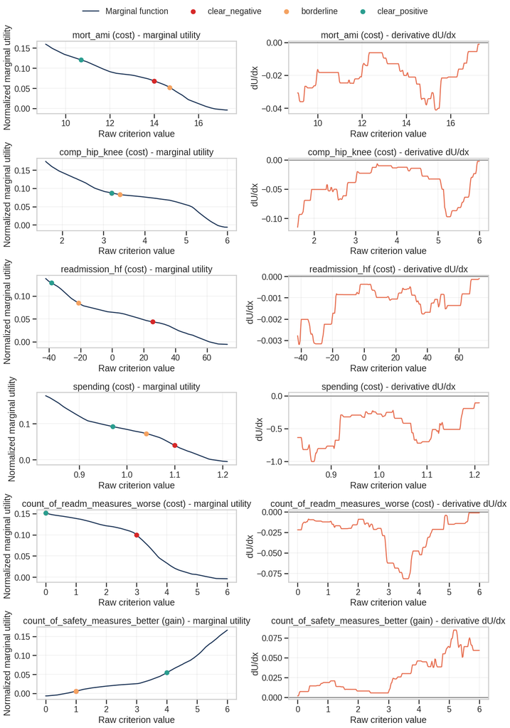

```
Selected alternatives (raw criteria):
```

|  | case | mort_ami | comp_hip_knee | readmission_hf | spending | count_of_readm_measures_worse | count_of_safety_measures_better |
| --- | --- | --- | --- | --- | --- | --- | --- |
| 0 | clear_negative | 14.0 | 3.2 | 25.7 | 1.10 | 3.0 | 1.0 |
| 1 | borderline | 14.7 | 3.4 | -21.4 | 1.04 | 0.0 | 1.0 |
| 2 | clear_positive | 10.7 | 3.2 | -38.3 | 0.97 | 0.0 | 4.0 |

```
Monotonicity diagnostics in raw criterion units:
```

|  | criterion | type | expected_dUdx_sign | mean_dUdx | min_dUdx | max_dUdx | share_expected_sign |
| --- | --- | --- | --- | --- | --- | --- | --- |
| 0 | mort_ami | cost | negative | -0.019953 | -0.041203 | -0.001060 | 1.0 |
| 1 | comp_hip_knee | cost | negative | -0.040951 | -0.115240 | -0.002678 | 1.0 |
| 2 | readmission_hf | cost | negative | -0.001255 | -0.003190 | -0.000106 | 1.0 |
| 3 | spending | cost | negative | -0.481327 | -1.003672 | -0.107886 | 1.0 |
| 4 | count_of_readm_measures_worse | cost | negative | -0.025833 | -0.081530 | -0.001439 | 1.0 |
| 5 | count_of_safety_measures_better | gain | positive | 0.028968 | 0.001725 | 0.084755 | 1.0 |

```python
def ann_norm_denom(model) -> float:
    with torch.no_grad():
        zero = torch.zeros((1, len(feature_cols)), dtype=torch.float32)
        one = torch.ones((1, len(feature_cols)), dtype=torch.float32)
        u0 = model.utility_model(zero)
        u1 = model.utility_model(one)
        denom = float((u1 - u0).item())
    return max(denom, 1e-8)


def raw_to_pref_value(raw_values: np.ndarray, feat: str) -> np.ndarray:
    lo = float(ann_scaler.min_[feat])
    hi = float(ann_scaler.max_[feat])
    span = hi - lo
    if span <= 1e-12:
        return np.ones_like(raw_values) if feat in cost_cols else np.zeros_like(raw_values)
    if feat in gain_cols:
        pref = (raw_values - lo) / span
    else:
        pref = 1.0 - (raw_values - lo) / span
    return np.clip(pref, 0.0, 1.0)


def ann_marginal_curve_raw(model, feat: str, grid_size: int = 250) -> tuple[np.ndarray, np.ndarray, np.ndarray]:
    j = feature_cols.index(feat)
    x_raw = np.linspace(float(ann_scaler.min_[feat]), float(ann_scaler.max_[feat]), grid_size)
    x_pref = raw_to_pref_value(x_raw, feat)

    Xg = np.zeros((grid_size, len(feature_cols)), dtype=np.float32)
    Xg[:, j] = x_pref.astype(np.float32)

    denom = ann_norm_denom(model)
    with torch.no_grad():
        marg = model.utility_model.monotonic_layer(torch.tensor(Xg, dtype=torch.float32))[:, j]
        marg = marg.detach().cpu().numpy() / denom

    dmarg_dx = np.gradient(marg, x_raw)
    return x_raw, marg, dmarg_dx


def ann_marginal_value_for_points(model, feat: str, raw_values: np.ndarray) -> np.ndarray:
    j = feature_cols.index(feat)
    x_pref = raw_to_pref_value(raw_values, feat)
    Xp = np.zeros((len(raw_values), len(feature_cols)), dtype=np.float32)
    Xp[:, j] = x_pref.astype(np.float32)

    denom = ann_norm_denom(model)
    with torch.no_grad():
        vals = model.utility_model.monotonic_layer(torch.tensor(Xp, dtype=torch.float32))[:, j]
        vals = vals.detach().cpu().numpy() / denom
    return vals


case_order = ["clear_negative", "borderline", "clear_positive"]
selected_idx = [selected_indices[c] for c in case_order]
X_sel_raw = X_test_raw.loc[selected_idx, feature_cols].reset_index(drop=True)

color_map = {
    "clear_negative": "#D62828",
    "borderline": "#F4A261",
    "clear_positive": "#2A9D8F",
}

fig, axes = plt.subplots(len(feature_cols), 2, figsize=(14, 3.4 * len(feature_cols)))
if len(feature_cols) == 1:
    axes = np.array([axes])

diagnostics = []

for r, feat in enumerate(feature_cols):
    x_raw, marg_curve, dmarg_dx = ann_marginal_curve_raw(ann_model, feat, grid_size=300)

    ax_left = axes[r, 0]
    ax_left.plot(x_raw, marg_curve, color="#1D3557", linewidth=2, label="Marginal function")

    point_x = X_sel_raw[feat].to_numpy(dtype=float)
    point_y = ann_marginal_value_for_points(ann_model, feat, point_x)

    for k, case in enumerate(case_order):
        ax_left.scatter(
            [float(point_x[k])],
            [float(point_y[k])],
            s=70,
            color=color_map[case],
            label=case if r == 0 else None,
            zorder=3,
        )

    nature = "gain" if feat in gain_cols else "cost"
    ax_left.set_title(f"{feat} ({nature}) - marginal utility")
    ax_left.set_xlabel("Raw criterion value")
    ax_left.set_ylabel("Normalized marginal utility")
    ax_left.grid(alpha=0.25)

    ax_right = axes[r, 1]
    ax_right.plot(x_raw, dmarg_dx, color="#E76F51", linewidth=2)
    ax_right.axhline(0.0, color="black", linewidth=1, alpha=0.8)
    ax_right.set_title(f"{feat} ({nature}) - derivative dU/dx")
    ax_right.set_xlabel("Raw criterion value")
    ax_right.set_ylabel("dU/dx")
    ax_right.grid(alpha=0.25)

    expected = "positive" if feat in gain_cols else "negative"
    sign_ok_share = float((dmarg_dx >= -1e-7).mean()) if feat in gain_cols else float((dmarg_dx <= 1e-7).mean())
    diagnostics.append(
        {
            "criterion": feat,
            "type": nature,
            "expected_dUdx_sign": expected,
            "mean_dUdx": float(np.mean(dmarg_dx)),
            "min_dUdx": float(np.min(dmarg_dx)),
            "max_dUdx": float(np.max(dmarg_dx)),
            "share_expected_sign": sign_ok_share,
        }
    )

handles, labels = axes[0, 0].get_legend_handles_labels()
fig.legend(handles, labels, loc="upper center", ncol=4)
plt.tight_layout(rect=[0, 0, 1, 0.97])
plt.show()

print("Selected alternatives (raw criteria):")
ann_selected_table = X_sel_raw.copy()
ann_selected_table.insert(0, "case", case_order)
display(ann_selected_table)

print("Monotonicity diagnostics in raw criterion units:")
diag_df = pd.DataFrame(diagnostics)
display(diag_df.round(6))
```

### XGBoost: Tree Structure and Decision Paths for Selected Alternatives

This subsection provides a direct tree-based explanation for the three selected alternatives:

- a compact visualization of the first trees in the ensemble,
- per-alternative decision path in Tree 0,
- per-alternative tree-contribution decomposition (feature contributions + bias).

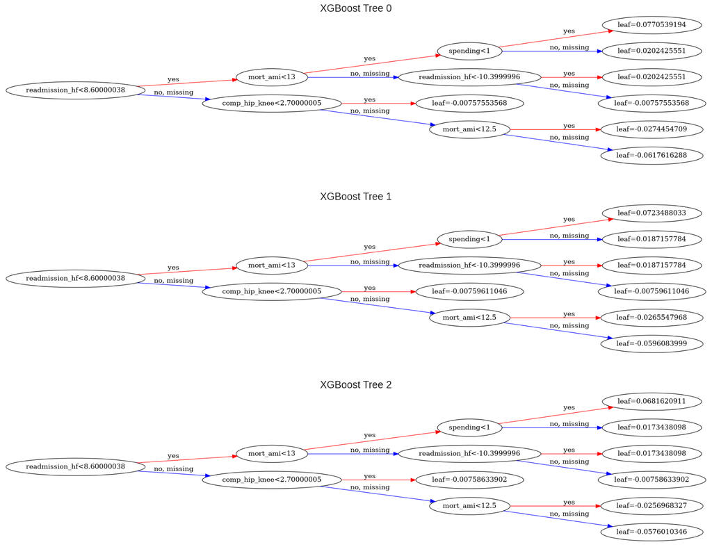

```
================================================================================
XGBoost Tree 0 decision path for case: clear_negative (test index 35)
Node 0: readmission_hf >= 8.6000 (value=25.7000) -> next 2
  Node 2: comp_hip_knee >= 2.7000 (value=3.2000) -> next 6
    Node 6: mort_ami >= 12.5000 (value=14.0000) -> next 12
      -> Leaf node 12 with leaf value -0.061762
================================================================================
XGBoost Tree 0 decision path for case: borderline (test index 0)
Node 0: readmission_hf < 8.6000 (value=-21.4000) -> next 1
  Node 1: mort_ami >= 13.0000 (value=14.7000) -> next 4
    Node 4: readmission_hf < -10.4000 (value=-21.4000) -> next 9
      -> Leaf node 9 with leaf value 0.020243
================================================================================
XGBoost Tree 0 decision path for case: clear_positive (test index 53)
Node 0: readmission_hf < 8.6000 (value=-38.3000) -> next 1
  Node 1: mort_ami < 13.0000 (value=10.7000) -> next 3
    Node 3: spending < 1.0000 (value=0.9700) -> next 7
      -> Leaf node 7 with leaf value 0.077054
```

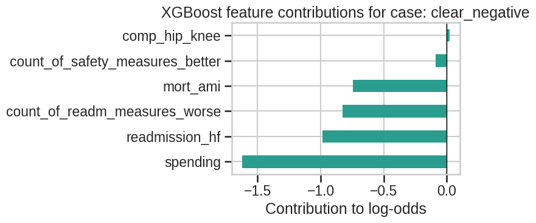

```
Bias term: -0.4250
Total log-odds: -4.6751
Predicted probability: 0.0092
```

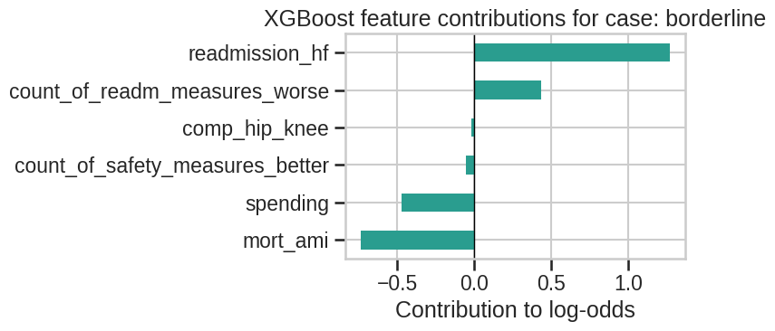

```
Bias term: -0.4250
Total log-odds: -0.0014
Predicted probability: 0.4996
```

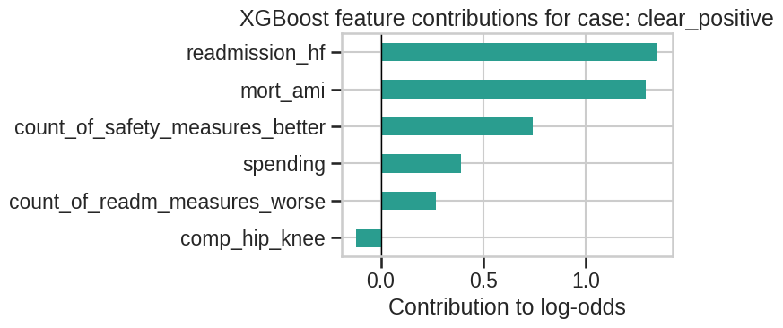

```
Bias term: -0.4250
Total log-odds: 3.5061
Predicted probability: 0.9709
```

```python
import xgboost as xgb

booster = xgb_model.get_booster()
num_trees_to_plot = min(3, xgb_model.n_estimators)

fig = None

try:
    fig, axes = plt.subplots(num_trees_to_plot, 1, figsize=(18, 4.8 * num_trees_to_plot))
    if num_trees_to_plot == 1:
        axes = [axes]

    for i in range(num_trees_to_plot):
        xgb.plot_tree(booster, num_trees=i, rankdir="LR", ax=axes[i])
        axes[i].set_title(f"XGBoost Tree {i}")

    plt.tight_layout()
    plt.show()
except Exception as e:
    if fig is not None:
        plt.close(fig)
    print("Graphviz tree drawing unavailable. Continuing with decision-path and contribution visualizations.")
    print(f"Reason: {e}")


def _to_node_id(v) -> int:
    s = str(v)
    if "-" in s:
        s = s.split("-")[-1]
    return int(float(s))


def trace_tree_path(tree_df: pd.DataFrame, x_row: pd.Series) -> list[dict]:
    tdf = tree_df.copy()
    tdf["Node"] = tdf["Node"].astype(int)
    tdf = tdf.set_index("Node")

    node = 0
    rows: list[dict] = []

    while True:
        r = tdf.loc[node]
        feature = str(r["Feature"])
        if feature == "Leaf":
            rows.append(
                {
                    "node": node,
                    "feature": "Leaf",
                    "leaf_value": float(r["Gain"]),
                }
            )
            break

        split = float(r["Split"])
        value = float(x_row[feature])
        go_yes = value < split
        next_node = _to_node_id(r["Yes"] if go_yes else r["No"])

        rows.append(
            {
                "node": node,
                "feature": feature,
                "split": split,
                "value": value,
                "direction": "<" if go_yes else ">=",
                "next_node": next_node,
            }
        )
        node = next_node

    return rows


trees_df = booster.trees_to_dataframe()
tree0 = trees_df[trees_df["Tree"] == 0].copy()

for case, idx in selected_indices.items():
    x_row = X_test_raw.loc[idx, feature_cols]
    path_rows = trace_tree_path(tree0, x_row)

    print("=" * 80)
    print(f"XGBoost Tree 0 decision path for case: {case} (test index {idx})")
    for step, item in enumerate(path_rows):
        indent = "  " * step
        if item["feature"] == "Leaf":
            print(f"{indent}-> Leaf node {item['node']} with leaf value {item['leaf_value']:.6f}")
        else:
            print(
                f"{indent}Node {item['node']}: {item['feature']} {item['direction']} {item['split']:.4f} "
                f"(value={item['value']:.4f}) -> next {item['next_node']}"
            )

for case, idx in selected_indices.items():
    x_row_df = X_test_raw.loc[[idx], feature_cols]
    dm = xgb.DMatrix(x_row_df)
    contrib = booster.predict(dm, pred_contribs=True)[0]
    contrib_s = pd.Series(contrib, index=feature_cols + ["bias"])

    fig, ax = plt.subplots(figsize=(8, 4))
    contrib_s.drop("bias").sort_values().plot(kind="barh", ax=ax, color="#2A9D8F")
    ax.axvline(0, color="black", linewidth=1)
    ax.set_title(f"XGBoost feature contributions for case: {case}")
    ax.set_xlabel("Contribution to log-odds")
    plt.tight_layout()
    plt.show()

    print(f"Bias term: {contrib_s['bias']:.4f}")
    print(f"Total log-odds: {contrib_s.sum():.4f}")
    print(f"Predicted probability: {float(model_prob('XGBoost', x_row_df)[0]):.4f}")
```

### SHAP

```
Case: clear_negative
XGBoost SHAP contribution bar:
```

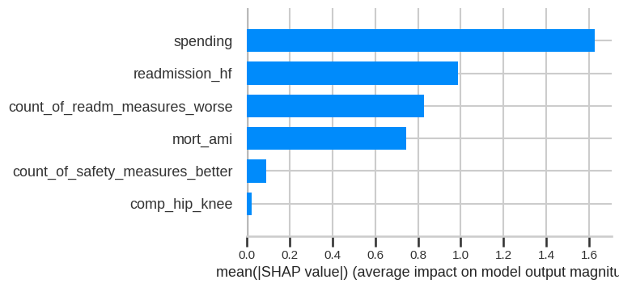

```
StandardNN SHAP contribution bar:
```

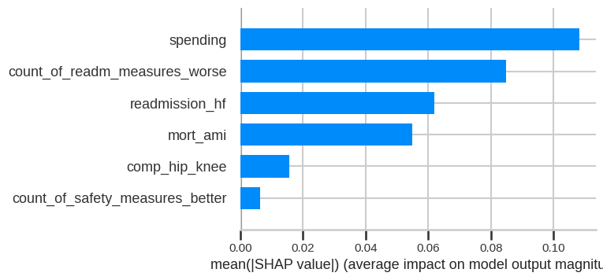

```
ANN-UTADIS SHAP contribution bar:
```

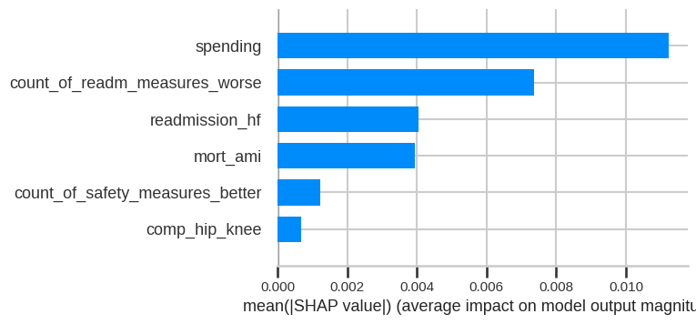

```
Case: borderline
XGBoost SHAP contribution bar:
```

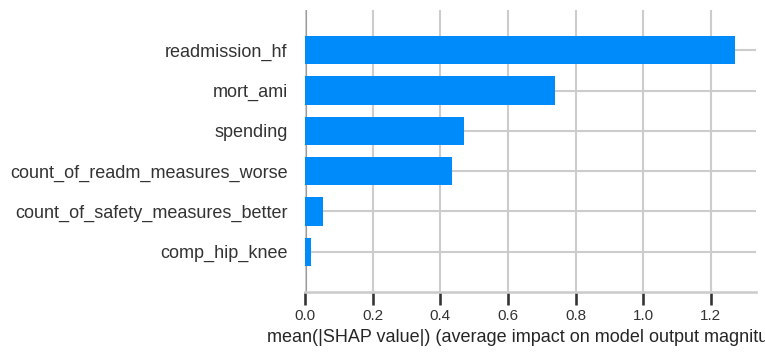

```
StandardNN SHAP contribution bar:
```

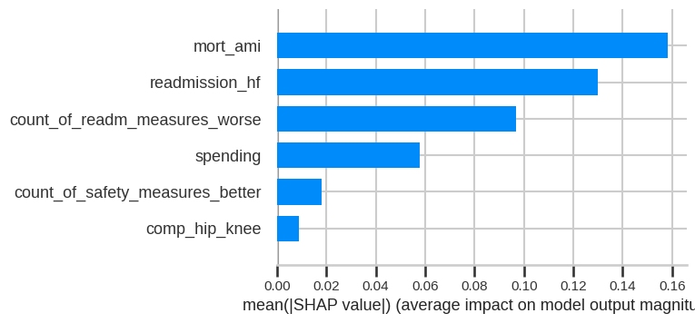

```
ANN-UTADIS SHAP contribution bar:
```

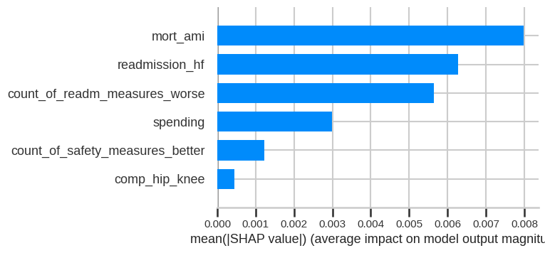

```
Case: clear_positive
XGBoost SHAP contribution bar:
```

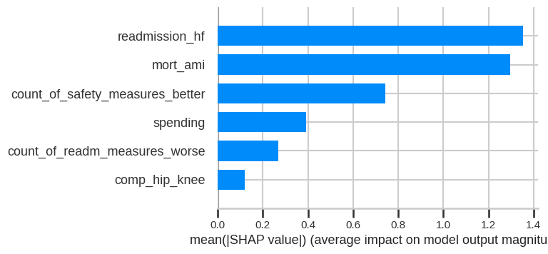

```
StandardNN SHAP contribution bar:
```

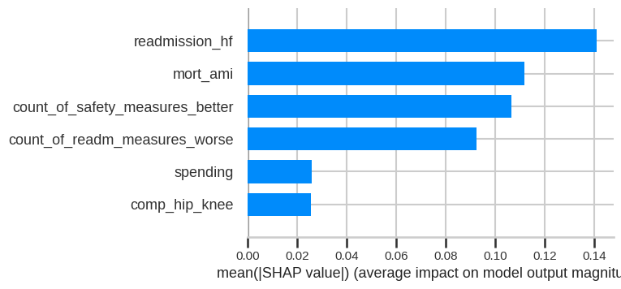

```
ANN-UTADIS SHAP contribution bar:
```

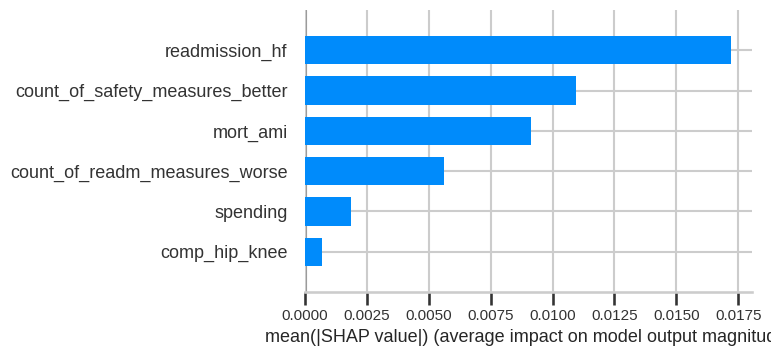

```python
# SHAP local explanations (for selected alternatives)
if HAS_SHAP:
    bg = X_train_raw.sample(n=min(100, len(X_train_raw)), random_state=SEED)

    xgb_explainer = shap.TreeExplainer(xgb_model)
    shap_xgb = xgb_explainer.shap_values(X_test_raw[feature_cols])

    def stdnn_prob_fn(arr):
        X_df = pd.DataFrame(arr, columns=feature_cols)
        return predict_stdnn(X_df)[1]

    def ann_prob_fn(arr):
        X_df = pd.DataFrame(arr, columns=feature_cols)
        return predict_ann(X_df)[1]

    stdnn_explainer = shap.KernelExplainer(stdnn_prob_fn, bg[feature_cols], link="identity")
    ann_explainer = shap.KernelExplainer(ann_prob_fn, bg[feature_cols], link="identity")

    sample_rows = [selected_indices[k] for k in ["clear_negative", "borderline", "clear_positive"]]
    X_local = X_test_raw.loc[sample_rows, feature_cols]

    shap_stdnn = stdnn_explainer.shap_values(X_local, nsamples=200)
    shap_ann = ann_explainer.shap_values(X_local, nsamples=200)

    for i, case in enumerate(["clear_negative", "borderline", "clear_positive"]):
        print(f"\nCase: {case}")

        print("XGBoost SHAP contribution bar:")
        shap.summary_plot(np.array([shap_xgb[sample_rows[i]]]), X_test_raw.loc[[sample_rows[i]], feature_cols], plot_type="bar", show=True)

        print("StandardNN SHAP contribution bar:")
        shap.summary_plot(np.array([shap_stdnn[i]]), X_local.iloc[[i]], plot_type="bar", show=True)

        print("ANN-UTADIS SHAP contribution bar:")
        shap.summary_plot(np.array([shap_ann[i]]), X_local.iloc[[i]], plot_type="bar", show=True)
else:
    print("SHAP not available; skipping SHAP local explanations.")
```

### DALEX

```python
# DALEX local explanations
if HAS_DALEX:
    X_train_df = X_train_raw[feature_cols].copy()

    expl_xgb = dx.Explainer(
        xgb_model,
        X_train_df,
        y_train,
        predict_function=lambda m, d: m.predict_proba(d)[:, 1],
        label="XGBoost",
        verbose=False,
    )

    expl_stdnn = dx.Explainer(
        stdnn_model,
        X_train_df,
        y_train,
        predict_function=lambda m, d: predict_stdnn(d)[1],
        label="StandardNN",
        verbose=False,
    )

    expl_ann = dx.Explainer(
        ann_model,
        X_train_df,
        y_train,
        predict_function=lambda m, d: predict_ann(d)[1],
        label="ANN-UTADIS",
        verbose=False,
    )

    dalex_explainers = [expl_xgb, expl_stdnn, expl_ann]

    for case, idx in selected_indices.items():
        obs = X_test_raw.loc[[idx], feature_cols]
        print("=" * 60)
        print(f"\nDALEX break-down for case: {case}")
        print(f"True class: {y_test[idx]}, XGBoost prob: {fmt4(xgb_prob[idx])}, StandardNN prob: {fmt4(local_pred_cache['StandardNN']['prob'][idx])}, ANN-UTADIS prob: {fmt4(local_pred_cache['ANN-UTADIS']['prob'][idx])}")
        for expl in dalex_explainers:
            bd = expl.predict_parts(obs, type="break_down")
            print(f"Model: {expl.label}")
            display(bd.result.head(12))
else:
    print("DALEX not available; skipping DALEX local explanations.")
```

```
============================================================

DALEX break-down for case: clear_negative
True class: 0, XGBoost prob: 0.0092, StandardNN prob: 0.0504, ANN-UTADIS prob: 0.4688
Model: XGBoost
```

|  | variable_name | variable_value | variable | cumulative | contribution | sign | position | label |
| --- | --- | --- | --- | --- | --- | --- | --- | --- |
| 0 | intercept |  | intercept | 0.397582 | 0.397582 | 1.0 | 7 | XGBoost |
| 1 | comp_hip_knee | 3.2 | comp_hip_knee = 3.2 | 0.395479 | -0.002103 | -1.0 | 6 | XGBoost |
| 2 | count_of_safety_measures_better | 1.0 | count_of_safety_measures_better = 1.0 | 0.386621 | -0.008858 | -1.0 | 5 | XGBoost |
| 3 | count_of_readm_measures_worse | 3.0 | count_of_readm_measures_worse = 3.0 | 0.274280 | -0.112341 | -1.0 | 4 | XGBoost |
| 4 | mort_ami | 14.0 | mort_ami = 14.0 | 0.125698 | -0.148582 | -1.0 | 3 | XGBoost |
| 5 | readmission_hf | 25.7 | readmission_hf = 25.7 | 0.041430 | -0.084268 | -1.0 | 2 | XGBoost |
| 6 | spending | 1.1 | spending = 1.1 | 0.009238 | -0.032191 | -1.0 | 1 | XGBoost |
| 7 |  |  | prediction | 0.009238 | 0.009238 | 1.0 | 0 | XGBoost |

```
Model: StandardNN
```

|  | variable_name | variable_value | variable | cumulative | contribution | sign | position | label |
| --- | --- | --- | --- | --- | --- | --- | --- | --- |
| 0 | intercept |  | intercept | 0.390156 | 0.390156 | 1.0 | 7 | StandardNN |
| 1 | comp_hip_knee | 3.2 | comp_hip_knee = 3.2 | 0.419746 | 0.029589 | 1.0 | 6 | StandardNN |
| 2 | count_of_safety_measures_better | 1.0 | count_of_safety_measures_better = 1.0 | 0.399066 | -0.020680 | -1.0 | 5 | StandardNN |
| 3 | readmission_hf | 25.7 | readmission_hf = 25.7 | 0.294840 | -0.104226 | -1.0 | 4 | StandardNN |
| 4 | mort_ami | 14.0 | mort_ami = 14.0 | 0.186761 | -0.108080 | -1.0 | 3 | StandardNN |
| 5 | spending | 1.1 | spending = 1.1 | 0.091362 | -0.095399 | -1.0 | 2 | StandardNN |
| 6 | count_of_readm_measures_worse | 3.0 | count_of_readm_measures_worse = 3.0 | 0.050397 | -0.040965 | -1.0 | 1 | StandardNN |
| 7 |  |  | prediction | 0.050397 | 0.050397 | 1.0 | 0 | StandardNN |

```
Model: ANN-UTADIS
```

|  | variable_name | variable_value | variable | cumulative | contribution | sign | position | label |
| --- | --- | --- | --- | --- | --- | --- | --- | --- |
| 0 | intercept |  | intercept | 0.498380 | 0.498380 | 1.0 | 7 | ANN-UTADIS |
| 1 | comp_hip_knee | 3.2 | comp_hip_knee = 3.2 | 0.499024 | 0.000644 | 1.0 | 6 | ANN-UTADIS |
| 2 | count_of_safety_measures_better | 1.0 | count_of_safety_measures_better = 1.0 | 0.497449 | -0.001575 | -1.0 | 5 | ANN-UTADIS |
| 3 | mort_ami | 14.0 | mort_ami = 14.0 | 0.492972 | -0.004477 | -1.0 | 4 | ANN-UTADIS |
| 4 | readmission_hf | 25.7 | readmission_hf = 25.7 | 0.488469 | -0.004503 | -1.0 | 3 | ANN-UTADIS |
| 5 | count_of_readm_measures_worse | 3.0 | count_of_readm_measures_worse = 3.0 | 0.479906 | -0.008563 | -1.0 | 2 | ANN-UTADIS |
| 6 | spending | 1.1 | spending = 1.1 | 0.468808 | -0.011098 | -1.0 | 1 | ANN-UTADIS |
| 7 |  |  | prediction | 0.468808 | 0.468808 | 1.0 | 0 | ANN-UTADIS |

```
============================================================

DALEX break-down for case: borderline
True class: 0, XGBoost prob: 0.4996, StandardNN prob: 0.3526, ANN-UTADIS prob: 0.4952
Model: XGBoost
```

|  | variable_name | variable_value | variable | cumulative | contribution | sign | position | label |
| --- | --- | --- | --- | --- | --- | --- | --- | --- |
| 0 | intercept |  | intercept | 0.397582 | 0.397582 | 1.0 | 7 | XGBoost |
| 1 | readmission_hf | -21.4 | readmission_hf = -21.4 | 0.615249 | 0.217667 | 1.0 | 6 | XGBoost |
| 2 | count_of_readm_measures_worse | 0.0 | count_of_readm_measures_worse = 0.0 | 0.691177 | 0.075929 | 1.0 | 5 | XGBoost |
| 3 | comp_hip_knee | 3.4 | comp_hip_knee = 3.4 | 0.698323 | 0.007146 | 1.0 | 4 | XGBoost |
| 4 | count_of_safety_measures_better | 1.0 | count_of_safety_measures_better = 1.0 | 0.686190 | -0.012133 | -1.0 | 3 | XGBoost |
| 5 | spending | 1.04 | spending = 1.04 | 0.574483 | -0.111707 | -1.0 | 2 | XGBoost |
| 6 | mort_ami | 14.7 | mort_ami = 14.7 | 0.499646 | -0.074837 | -1.0 | 1 | XGBoost |
| 7 |  |  | prediction | 0.499646 | 0.499646 | 1.0 | 0 | XGBoost |

```
Model: StandardNN
```

|  | variable_name | variable_value | variable | cumulative | contribution | sign | position | label |
| --- | --- | --- | --- | --- | --- | --- | --- | --- |
| 0 | intercept |  | intercept | 0.390156 | 0.390156 | 1.0 | 7 | StandardNN |
| 1 | readmission_hf | -21.4 | readmission_hf = -21.4 | 0.499734 | 0.109578 | 1.0 | 6 | StandardNN |
| 2 | count_of_readm_measures_worse | 0.0 | count_of_readm_measures_worse = 0.0 | 0.597689 | 0.097955 | 1.0 | 5 | StandardNN |
| 3 | comp_hip_knee | 3.4 | comp_hip_knee = 3.4 | 0.614138 | 0.016449 | 1.0 | 4 | StandardNN |
| 4 | count_of_safety_measures_better | 1.0 | count_of_safety_measures_better = 1.0 | 0.592709 | -0.021429 | -1.0 | 3 | StandardNN |
| 5 | spending | 1.04 | spending = 1.04 | 0.567285 | -0.025424 | -1.0 | 2 | StandardNN |
| 6 | mort_ami | 14.7 | mort_ami = 14.7 | 0.352626 | -0.214659 | -1.0 | 1 | StandardNN |
| 7 |  |  | prediction | 0.352626 | 0.352626 | 1.0 | 0 | StandardNN |

```
Model: ANN-UTADIS
```

|  | variable_name | variable_value | variable | cumulative | contribution | sign | position | label |
| --- | --- | --- | --- | --- | --- | --- | --- | --- |
| 0 | intercept |  | intercept | 0.498380 | 0.498380 | 1.0 | 7 | ANN-UTADIS |
| 1 | readmission_hf | -21.4 | readmission_hf = -21.4 | 0.504197 | 0.005817 | 1.0 | 6 | ANN-UTADIS |
| 2 | count_of_readm_measures_worse | 0.0 | count_of_readm_measures_worse = 0.0 | 0.508635 | 0.004437 | 1.0 | 5 | ANN-UTADIS |
| 3 | comp_hip_knee | 3.4 | comp_hip_knee = 3.4 | 0.508154 | -0.000481 | -1.0 | 4 | ANN-UTADIS |
| 4 | count_of_safety_measures_better | 1.0 | count_of_safety_measures_better = 1.0 | 0.506579 | -0.001575 | -1.0 | 3 | ANN-UTADIS |
| 5 | spending | 1.04 | spending = 1.04 | 0.503693 | -0.002886 | -1.0 | 2 | ANN-UTADIS |
| 6 | mort_ami | 14.7 | mort_ami = 14.7 | 0.495173 | -0.008520 | -1.0 | 1 | ANN-UTADIS |
| 7 |  |  | prediction | 0.495173 | 0.495173 | 1.0 | 0 | ANN-UTADIS |

```
============================================================

DALEX break-down for case: clear_positive
True class: 1, XGBoost prob: 0.9709, StandardNN prob: 0.8544, ANN-UTADIS prob: 0.5414
Model: XGBoost
```

|  | variable_name | variable_value | variable | cumulative | contribution | sign | position | label |
| --- | --- | --- | --- | --- | --- | --- | --- | --- |
| 0 | intercept |  | intercept | 0.397582 | 0.397582 | 1.0 | 7 | XGBoost |
| 1 | mort_ami | 10.7 | mort_ami = 10.7 | 0.616935 | 0.219354 | 1.0 | 6 | XGBoost |
| 2 | readmission_hf | -38.3 | readmission_hf = -38.3 | 0.826977 | 0.210042 | 1.0 | 5 | XGBoost |
| 3 | count_of_safety_measures_better | 4.0 | count_of_safety_measures_better = 4.0 | 0.920833 | 0.093855 | 1.0 | 4 | XGBoost |
| 4 | count_of_readm_measures_worse | 0.0 | count_of_readm_measures_worse = 0.0 | 0.934395 | 0.013562 | 1.0 | 3 | XGBoost |
| 5 | spending | 0.97 | spending = 0.97 | 0.968016 | 0.033621 | 1.0 | 2 | XGBoost |
| 6 | comp_hip_knee | 3.2 | comp_hip_knee = 3.2 | 0.970861 | 0.002846 | 1.0 | 1 | XGBoost |
| 7 |  |  | prediction | 0.970862 | 0.970862 | 1.0 | 0 | XGBoost |

```
Model: StandardNN
```

|  | variable_name | variable_value | variable | cumulative | contribution | sign | position | label |
| --- | --- | --- | --- | --- | --- | --- | --- | --- |
| 0 | intercept |  | intercept | 0.390156 | 0.390156 | 1.0 | 7 | StandardNN |
| 1 | readmission_hf | -38.3 | readmission_hf = -38.3 | 0.563327 | 0.173171 | 1.0 | 6 | StandardNN |
| 2 | mort_ami | 10.7 | mort_ami = 10.7 | 0.678801 | 0.115473 | 1.0 | 5 | StandardNN |
| 3 | count_of_safety_measures_better | 4.0 | count_of_safety_measures_better = 4.0 | 0.771908 | 0.093108 | 1.0 | 4 | StandardNN |
| 4 | count_of_readm_measures_worse | 0.0 | count_of_readm_measures_worse = 0.0 | 0.832950 | 0.061042 | 1.0 | 3 | StandardNN |
| 5 | spending | 0.97 | spending = 0.97 | 0.839891 | 0.006941 | 1.0 | 2 | StandardNN |
| 6 | comp_hip_knee | 3.2 | comp_hip_knee = 3.2 | 0.854396 | 0.014505 | 1.0 | 1 | StandardNN |
| 7 |  |  | prediction | 0.854396 | 0.854396 | 1.0 | 0 | StandardNN |

```
Model: ANN-UTADIS
```

|  | variable_name | variable_value | variable | cumulative | contribution | sign | position | label |
| --- | --- | --- | --- | --- | --- | --- | --- | --- |
| 0 | intercept |  | intercept | 0.498380 | 0.498380 | 1.0 | 7 | ANN-UTADIS |
| 1 | readmission_hf | -38.3 | readmission_hf = -38.3 | 0.515158 | 0.016778 | 1.0 | 6 | ANN-UTADIS |
| 2 | count_of_safety_measures_better | 4.0 | count_of_safety_measures_better = 4.0 | 0.525777 | 0.010619 | 1.0 | 5 | ANN-UTADIS |
| 3 | mort_ami | 10.7 | mort_ami = 10.7 | 0.534350 | 0.008572 | 1.0 | 4 | ANN-UTADIS |
| 4 | count_of_readm_measures_worse | 0.0 | count_of_readm_measures_worse = 0.0 | 0.538772 | 0.004422 | 1.0 | 3 | ANN-UTADIS |
| 5 | spending | 0.97 | spending = 0.97 | 0.540719 | 0.001948 | 1.0 | 2 | ANN-UTADIS |
| 6 | comp_hip_knee | 3.2 | comp_hip_knee = 3.2 | 0.541362 | 0.000642 | 1.0 | 1 | ANN-UTADIS |
| 7 |  |  | prediction | 0.541362 | 0.541362 | 1.0 | 0 | ANN-UTADIS |

### Summary

- The local attribution plots identify which criteria pushed each selected hospital toward class 0 or class 1.
- The analytical root-based minimum-change and sampling-based minimum-change are compared in normalized criterion space.
- Agreement is assessed with tolerance <= 0.01 in normalized change magnitude and shows consistency between the two methods.

## Global Interpretation of the Models

This section addresses:

- criteria influence,
- dependencies/interactions,
- criterion nature,
- preference thresholds and indifference regions.

```python
from sklearn.base import BaseEstimator, ClassifierMixin


class WrapperEstimator(BaseEstimator, ClassifierMixin):
    _estimator_type = "classifier"

    def __init__(self, model_name: str):
        self.model_name = model_name
        self.classes_ = np.array([0, 1])
        self.n_features_in_ = len(feature_cols)

    def fit(self, X, y=None):
        return self

    def predict_proba(self, X):
        X_df = pd.DataFrame(X, columns=feature_cols)
        probs = predictors[self.model_name](X_df)[1].reshape(-1)
        return np.column_stack([1.0 - probs, probs])

    def predict(self, X):
        return (self.predict_proba(X)[:, 1] >= 0.5).astype(int)


wrapped_estimators = {name: WrapperEstimator(name) for name in predictors}
```

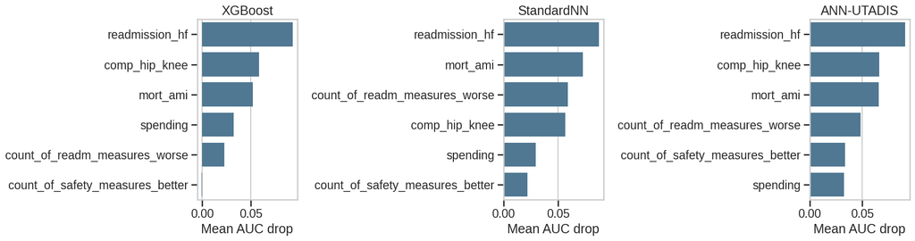

|  | model | feature | importance_mean | importance_std |
| --- | --- | --- | --- | --- |
| 14 | ANN-UTADIS | readmission_hf | 0.090604 | 0.024964 |
| 13 | ANN-UTADIS | comp_hip_knee | 0.066097 | 0.024249 |
| 12 | ANN-UTADIS | mort_ami | 0.065653 | 0.026260 |
| 16 | ANN-UTADIS | count_of_readm_measures_worse | 0.048583 | 0.020486 |
| 17 | ANN-UTADIS | count_of_safety_measures_better | 0.033819 | 0.019833 |
| 15 | ANN-UTADIS | spending | 0.032681 | 0.015924 |
| 8 | StandardNN | readmission_hf | 0.087181 | 0.023614 |
| 6 | StandardNN | mort_ami | 0.072681 | 0.023822 |
| 10 | StandardNN | count_of_readm_measures_worse | 0.058861 | 0.022730 |
| 7 | StandardNN | comp_hip_knee | 0.056361 | 0.020170 |
| 9 | StandardNN | spending | 0.029708 | 0.014150 |
| 11 | StandardNN | count_of_safety_measures_better | 0.022194 | 0.015477 |
| 2 | XGBoost | readmission_hf | 0.093444 | 0.031358 |
| 1 | XGBoost | comp_hip_knee | 0.058750 | 0.019263 |
| 0 | XGBoost | mort_ami | 0.051944 | 0.021283 |
| 3 | XGBoost | spending | 0.032424 | 0.017545 |
| 4 | XGBoost | count_of_readm_measures_worse | 0.022618 | 0.015945 |
| 5 | XGBoost | count_of_safety_measures_better | -0.000569 | 0.014042 |

```python
# Permutation Feature Importance (PFI)
from sklearn.metrics import roc_auc_score


def auc_scorer(estimator, X, y):
    probs = estimator.predict_proba(X)[:, 1]
    return roc_auc_score(y, probs)


pfi_rows = []
for model_name, est in wrapped_estimators.items():
    result = permutation_importance(
        est,
        X_test_raw[feature_cols],
        y_test,
        n_repeats=30,
        random_state=SEED,
        scoring=auc_scorer,
    )
    for feat, imp_mean, imp_std in zip(feature_cols, result.importances_mean, result.importances_std):
        pfi_rows.append({
            "model": model_name,
            "feature": feat,
            "importance_mean": float(imp_mean),
            "importance_std": float(imp_std),
        })

pfi_df = pd.DataFrame(pfi_rows)

fig, axes = plt.subplots(1, 3, figsize=(18, 5), sharex=False)
for ax, model_name in zip(axes, predictors.keys()):
    temp = pfi_df[pfi_df["model"] == model_name].sort_values("importance_mean", ascending=False)
    sns.barplot(data=temp, x="importance_mean", y="feature", ax=ax, color="#457B9D")
    ax.set_title(model_name)
    ax.set_xlabel("Mean AUC drop")
    ax.set_ylabel("")

plt.tight_layout()
plt.show()

pfi_df.sort_values(["model", "importance_mean"], ascending=[True, False]).head(18)
```

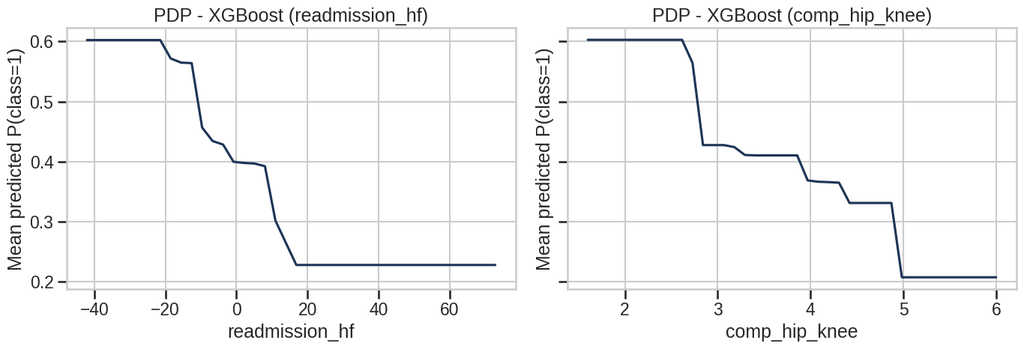

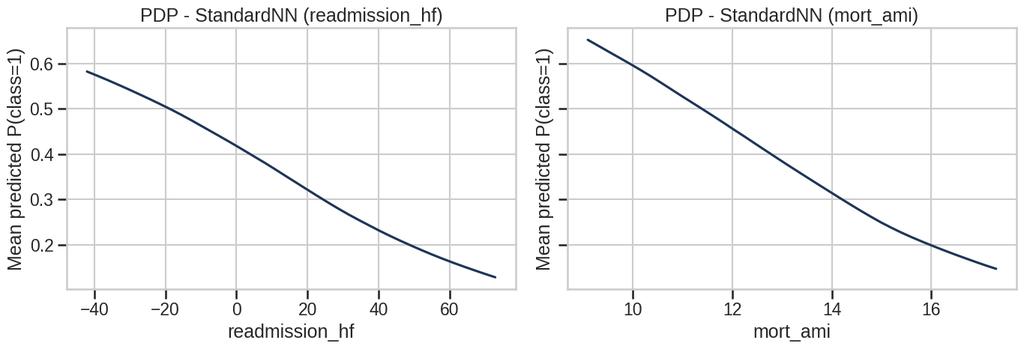

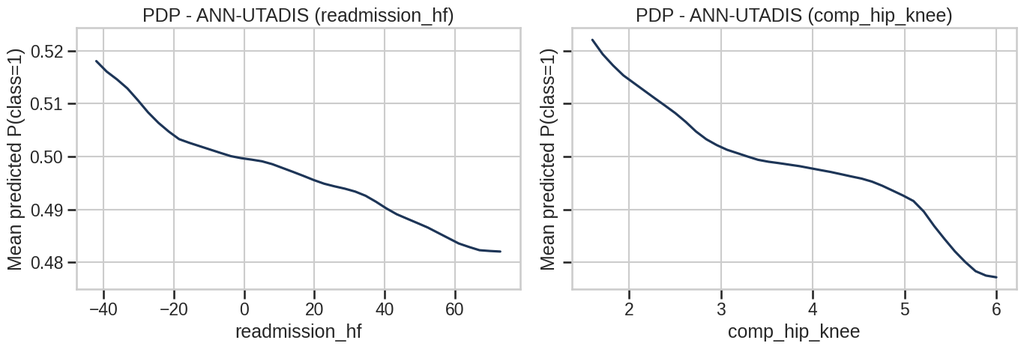

```
Top features per model:
{'XGBoost': ['readmission_hf', 'comp_hip_knee'], 'StandardNN': ['readmission_hf', 'mort_ami'], 'ANN-UTADIS': ['readmission_hf', 'comp_hip_knee']}
```

```python
# Partial Dependence Plots
# Top-2 criteria per model from PFI
top_features = {}
for model_name in predictors:
    temp = (
        pfi_df[pfi_df["model"] == model_name]
        .sort_values("importance_mean", ascending=False)
        .head(2)["feature"]
        .tolist()
    )
    top_features[model_name] = temp


def manual_pdp(model_name: str, X_ref: pd.DataFrame, feature: str, grid_resolution: int = 30):
    fmin = float(X_train_raw[feature].min())
    fmax = float(X_train_raw[feature].max())
    grid = np.linspace(fmin, fmax, grid_resolution)
    vals = []
    for g in grid:
        X_tmp = X_ref.copy()
        X_tmp[feature] = g
        vals.append(model_prob(model_name, X_tmp).mean())
    return grid, np.array(vals)


for model_name in predictors:
    feats = top_features[model_name]
    fig, axes = plt.subplots(1, len(feats), figsize=(7 * len(feats), 5), sharey=True)
    if len(feats) == 1:
        axes = [axes]
    for ax, feat in zip(axes, feats):
        grid, vals = manual_pdp(model_name, X_test_raw[feature_cols], feat, grid_resolution=40)
        ax.plot(grid, vals, color="#1D3557")
        ax.set_title(f"PDP - {model_name} ({feat})")
        ax.set_xlabel(feat)
        ax.set_ylabel("Mean predicted P(class=1)")
    plt.tight_layout()
    plt.show()

print("Top features per model:")
print(top_features)
```

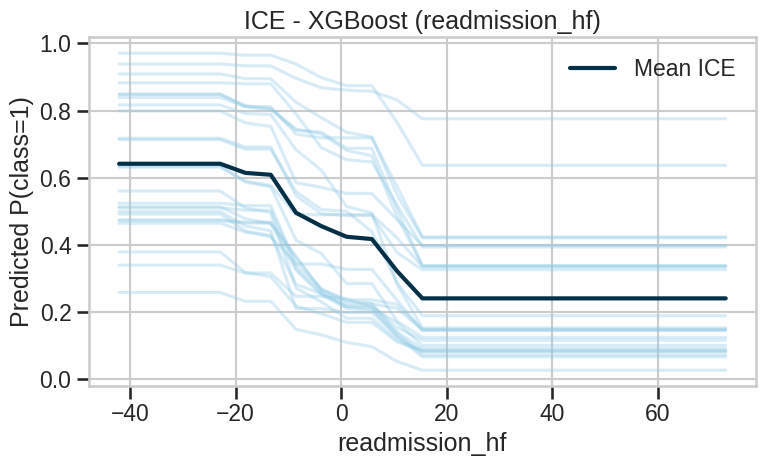

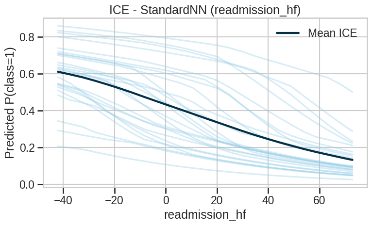

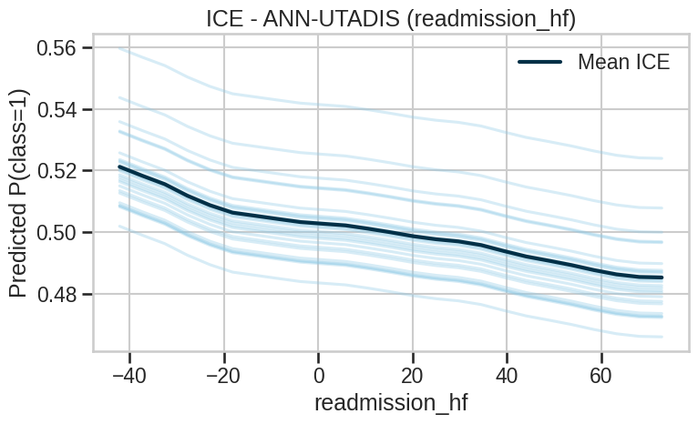

```python
# ICE plots
def manual_ice(model_name: str, X_ref: pd.DataFrame, feature: str, n_curves: int = 25, grid_resolution: int = 25):
    sample_idx = X_ref.sample(n=min(n_curves, len(X_ref)), random_state=SEED).index.tolist()
    fmin = float(X_train_raw[feature].min())
    fmax = float(X_train_raw[feature].max())
    grid = np.linspace(fmin, fmax, grid_resolution)

    curves = []
    for idx in sample_idx:
        x0 = X_ref.loc[idx, feature_cols].copy()
        vals = []
        for g in grid:
            x_new = x0.copy()
            x_new[feature] = g
            vals.append(float(model_prob(model_name, pd.DataFrame([x_new]))[0]))
        curves.append(vals)
    return grid, np.array(curves)


for model_name in predictors:
    feat = top_features[model_name][0]
    grid, curves = manual_ice(model_name, X_test_raw[feature_cols], feat)

    fig, ax = plt.subplots(figsize=(8, 5))
    for row in curves:
        ax.plot(grid, row, color="#8ECAE6", alpha=0.35)
    ax.plot(grid, curves.mean(axis=0), color="#023047", linewidth=3, label="Mean ICE")
    ax.set_title(f"ICE - {model_name} ({feat})")
    ax.set_xlabel(feat)
    ax.set_ylabel("Predicted P(class=1)")
    ax.legend()
    plt.tight_layout()
    plt.show()
```

```
Global SHAP summary for XGBoost:
```

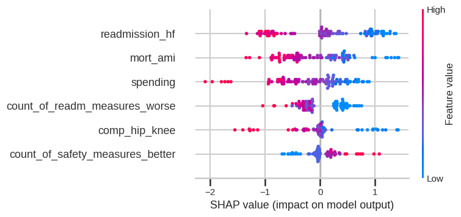

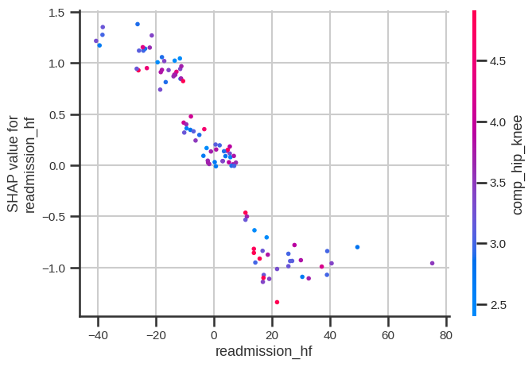

```
Global SHAP summary for StandardNN:
```

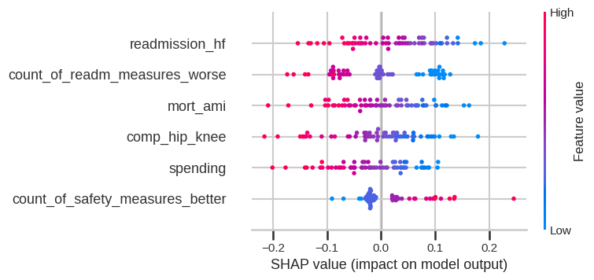

```
Global SHAP summary for ANN-UTADIS:
```

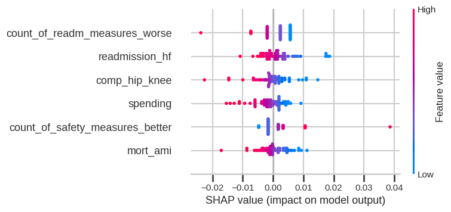

```python
# SHAP global interpretation
if HAS_SHAP:
    # XGBoost global
    print("Global SHAP summary for XGBoost:")
    shap_xgb_full = shap.TreeExplainer(xgb_model).shap_values(X_test_raw[feature_cols])
    shap.summary_plot(shap_xgb_full, X_test_raw[feature_cols], feature_names=feature_cols, show=True)

    # Dependence on top feature
    top_xgb_feat = top_features["XGBoost"][0]
    shap.dependence_plot(top_xgb_feat, shap_xgb_full, X_test_raw[feature_cols], show=True)

    bg_small = X_train_raw.sample(n=min(80, len(X_train_raw)), random_state=SEED)
    eval_small = X_test_raw.sample(n=min(60, len(X_test_raw)), random_state=SEED)

    stdnn_expl_global = shap.KernelExplainer(lambda a: predict_stdnn(pd.DataFrame(a, columns=feature_cols))[1], bg_small)
    ann_expl_global = shap.KernelExplainer(lambda a: predict_ann(pd.DataFrame(a, columns=feature_cols))[1], bg_small)

    shap_stdnn_full = stdnn_expl_global.shap_values(eval_small, nsamples=200)
    shap_ann_full = ann_expl_global.shap_values(eval_small, nsamples=200)

    print("Global SHAP summary for StandardNN:")
    shap.summary_plot(np.array(shap_stdnn_full), eval_small, feature_names=feature_cols, show=True)
    print("Global SHAP summary for ANN-UTADIS:")
    shap.summary_plot(np.array(shap_ann_full), eval_small, feature_names=feature_cols, show=True)
else:
    print("SHAP not available; skipping global SHAP section.")
```

```python
# DALEX global interpretation
if HAS_DALEX:
    X_train_df = X_train_raw[feature_cols].copy()

    expl_xgb_g = dx.Explainer(
        xgb_model,
        X_train_df,
        y_train,
        predict_function=lambda m, d: m.predict_proba(d)[:, 1],
        label="XGBoost",
        verbose=False,
    )
    expl_stdnn_g = dx.Explainer(
        stdnn_model,
        X_train_df,
        y_train,
        predict_function=lambda m, d: predict_stdnn(d)[1],
        label="StandardNN",
        verbose=False,
    )
    expl_ann_g = dx.Explainer(
        ann_model,
        X_train_df,
        y_train,
        predict_function=lambda m, d: predict_ann(d)[1],
        label="ANN-UTADIS",
        verbose=False,
    )

    for ex in [expl_xgb_g, expl_stdnn_g, expl_ann_g]:
        vi = ex.model_parts(type="variable_importance")
        print(f"\nDALEX Variable Importance: {ex.label}")
        display(vi.result.head(12))

    # Partial dependence profiles on two top features from XGBoost ranking
    candidate_feats = top_features["XGBoost"]
    for feat in candidate_feats:
        mp_xgb = expl_xgb_g.model_profile(type="partial", variables=[feat])
        mp_nn = expl_stdnn_g.model_profile(type="partial", variables=[feat])
        mp_ann = expl_ann_g.model_profile(type="partial", variables=[feat])
        mp_xgb.plot(objects=[mp_nn, mp_ann], geom="aggregates", title=f"DALEX Partial Dependence - {feat}")
else:
    print("DALEX not available; skipping DALEX global section.")
```

[output not shown]

```
DALEX Variable Importance: XGBoost
```

|  | variable | dropout_loss | label |
| --- | --- | --- | --- |
| 0 | _full_model_ | 0.107505 | XGBoost |
| 1 | count_of_safety_measures_better | 0.137226 | XGBoost |
| 2 | count_of_readm_measures_worse | 0.143445 | XGBoost |
| 3 | comp_hip_knee | 0.146396 | XGBoost |
| 4 | spending | 0.189803 | XGBoost |
| 5 | mort_ami | 0.215953 | XGBoost |
| 6 | readmission_hf | 0.223783 | XGBoost |
| 7 | _baseline_ | 0.504252 | XGBoost |

```
DALEX Variable Importance: StandardNN
```

|  | variable | dropout_loss | label |
| --- | --- | --- | --- |
| 0 | _full_model_ | 0.422322 | StandardNN |
| 1 | count_of_safety_measures_better | 0.433192 | StandardNN |
| 2 | comp_hip_knee | 0.433860 | StandardNN |
| 3 | spending | 0.440631 | StandardNN |
| 4 | count_of_readm_measures_worse | 0.441229 | StandardNN |
| 5 | readmission_hf | 0.444249 | StandardNN |
| 6 | mort_ami | 0.450162 | StandardNN |
| 7 | _baseline_ | 0.537353 | StandardNN |

```
DALEX Variable Importance: ANN-UTADIS
```

|  | variable | dropout_loss | label |
| --- | --- | --- | --- |
| 0 | _full_model_ | 0.493128 | ANN-UTADIS |
| 1 | count_of_safety_measures_better | 0.493545 | ANN-UTADIS |
| 2 | comp_hip_knee | 0.493836 | ANN-UTADIS |
| 3 | mort_ami | 0.494398 | ANN-UTADIS |
| 4 | readmission_hf | 0.494462 | ANN-UTADIS |
| 5 | spending | 0.494493 | ANN-UTADIS |
| 6 | count_of_readm_measures_worse | 0.494524 | ANN-UTADIS |
| 7 | _baseline_ | 0.500222 | ANN-UTADIS |

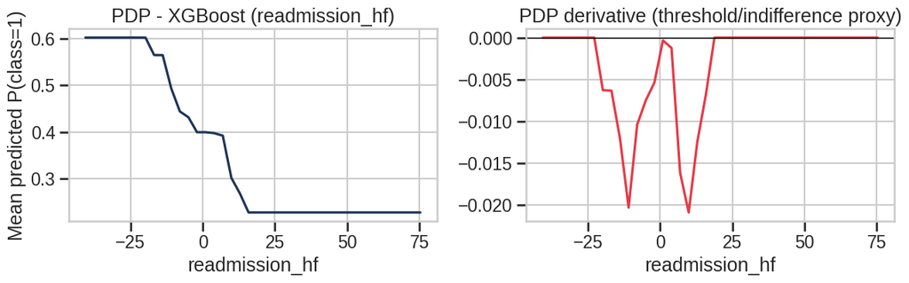

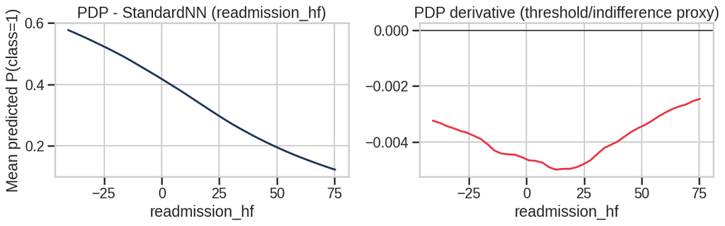

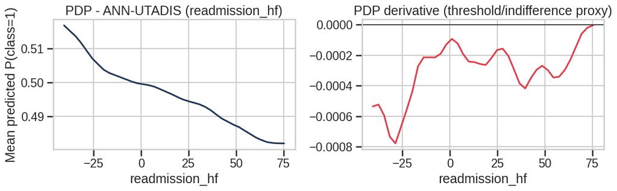

```
ANN-UTADIS learned threshold: 0.5009
ANN-UTADIS normalized score range on test: (0.3113, 0.6948)
Share of test alternatives near threshold (|score-th| <= 0.05): 0.6200
```

```python
# Threshold / indifference proxy from PDP flatness

def pdp_flat_regions(est, feature: str, X_ref: pd.DataFrame, grid_resolution: int = 40):
    fmin = float(X_ref[feature].min())
    fmax = float(X_ref[feature].max())
    grid = np.linspace(fmin, fmax, grid_resolution)
    vals = []

    X_tmp = X_ref.copy()
    for g in grid:
        X_tmp[feature] = g
        vals.append(est.predict_proba(X_tmp[feature_cols])[:, 1].mean())

    vals = np.array(vals)
    deriv = np.gradient(vals, grid)
    thresh = np.quantile(np.abs(deriv), 0.25)
    flat_idx = np.where(np.abs(deriv) <= thresh)[0]

    return pd.DataFrame({
        "grid": grid,
        "pdp": vals,
        "derivative": deriv,
        "is_flat_region": np.isin(np.arange(len(grid)), flat_idx),
    })

for model_name, est in wrapped_estimators.items():
    feat = top_features[model_name][0]
    prof = pdp_flat_regions(est, feat, X_test_raw[feature_cols])

    fig, axes = plt.subplots(1, 2, figsize=(12, 4))
    axes[0].plot(prof["grid"], prof["pdp"], color="#1D3557")
    axes[0].set_title(f"PDP - {model_name} ({feat})")
    axes[0].set_xlabel(feat)
    axes[0].set_ylabel("Mean predicted P(class=1)")

    axes[1].plot(prof["grid"], prof["derivative"], color="#E63946")
    axes[1].axhline(0.0, color="black", lw=1)
    axes[1].set_title("PDP derivative (threshold/indifference proxy)")
    axes[1].set_xlabel(feat)

    plt.tight_layout()
    plt.show()

# ANN-UTADIS explicit threshold parameter
ann_threshold = float(ann_model.threshold_layer.threshold.detach().cpu().numpy().reshape(-1)[0])
ann_scores = ann_model.predict_score(torch.tensor(ann_scaler.transform(X_test_raw[feature_cols]).values, dtype=torch.float32)).detach().cpu().numpy().reshape(-1)

print(f"ANN-UTADIS learned threshold: {ann_threshold:.4f}")
print(f"ANN-UTADIS normalized score range on test: ({ann_scores.min():.4f}, {ann_scores.max():.4f})")
print(f"Share of test alternatives near threshold (|score-th| <= 0.05): {np.mean(np.abs(ann_scores - ann_threshold) <= 0.05):.4f}")
```

## Conclusions

```python
best_auc_model = metrics_df["auc"].idxmax()
best_auc_value = float(metrics_df.loc[best_auc_model, "auc"])

best_f1_model = metrics_df["f1"].idxmax()
best_f1_value = float(metrics_df.loc[best_f1_model, "f1"])

top_pfi = (
    pfi_df.sort_values(["model", "importance_mean"], ascending=[True, False])
    .groupby("model")
    .head(1)
    [["model", "feature", "importance_mean"]]
)

print("Performance summary")
print(f"- Best AUC: {best_auc_model} ({best_auc_value:.4f})")
print(f"- Best F1: {best_f1_model} ({best_f1_value:.4f})")
print("\nMost influential criterion by PFI per model")
display(top_pfi)

print("\nInterpretation notes")
print("1. Criteria with high PFI and strong SHAP magnitude are decisive in the learned preference structure.")
print("2. Flat PDP fragments indicate indifference ranges; sharp PDP changes indicate practical preference thresholds.")
print("3. For ANN-UTADIS, interpretation around the learned threshold should focus on alternatives with scores near that threshold.")
```

```
Performance summary
- Best AUC: ANN-UTADIS (0.9050)
- Best F1: StandardNN (0.7848)

Most influential criterion by PFI per model
```

|  | model | feature | importance_mean |
| --- | --- | --- | --- |
| 14 | ANN-UTADIS | readmission_hf | 0.090604 |
| 8 | StandardNN | readmission_hf | 0.087181 |
| 2 | XGBoost | readmission_hf | 0.093444 |

```
Interpretation notes
1. Criteria with high PFI and strong SHAP magnitude are decisive in the learned preference structure.
2. Flat PDP fragments indicate indifference ranges; sharp PDP changes indicate practical preference thresholds.
3. For ANN-UTADIS, interpretation around the learned threshold should focus on alternatives with scores near that threshold.
```